# Statistical Models and Computing

Yaniv Bronshtein

3/1/2022

**Import the necessary libraries**

```r
library(MASS)
library(pid)
library(hnp)
```

# Problem 1.

We want to test the effect of light level and amount of water on the yield of tomato plants. Each potted plant receives one of three levels of light (1 = 5 hours, 2 = 10 hours, 3 = 15 hours) and one of two levels of water (1 = 1 quart, 2 = 2 quarts). The yield, in pounds, is recorded. The results are as follows: **Read in the data**

```r
path1 <- '/Users/yanivbronshtein/Coding/Rutgers/Statistical_Computing_Repo/data/hw2_q1_data.txt'
q1_df <- read.table(path1,header=TRUE)
lm_fit <- lm(Yield~., data=q1_df)
```

**Now let us print the summary object**

```r
summary(lm_fit)
```

```
##
## Call:
## lm(formula = Yield ~ ., data = q1_df)
##
## Residuals:
##     Min      1Q  Median      3Q     Max
## -3.6667 -0.9514 -0.2778  1.3750  4.1944
##
## Coefficients:
##             Estimate Std. Error t value Pr(>|t|)
## (Intercept)  -1.7222     2.3703  -0.727  0.47866
## Light         5.9167     0.7257   8.153 6.82e-07 ***
## Water         4.7778     1.1851   4.031  0.00109 **
## ---
## Signif. codes:  0 '***' 0.001 '**' 0.01 '*' 0.05 '.' 0.1 ' ' 1
##
## Residual standard error: 2.514 on 15 degrees of freedom
## Multiple R-squared:  0.8465, Adjusted R-squared:  0.826
## F-statistic: 41.36 on 2 and 15 DF,  p-value: 7.868e-07
```

*Light is and Water are both significant factors in determining yield because the p-value is less than 0.05* *This supports the hypothesis that increasing light exposure and water exposure will lead to higher yield* # Problem 2 The following data responses y are generated from a regular Poisson model with a single covariate variable x.

(a). Please write down the Poisson model for this data set, stating all requirements.

```r
path2 <- '/Users/yanivbronshtein/Coding/Rutgers/Statistical_Computing_Repo/data/hw2_q2_data.txt'
q2_df <- read.table(path2, header=TRUE)
```

**Plot the data**

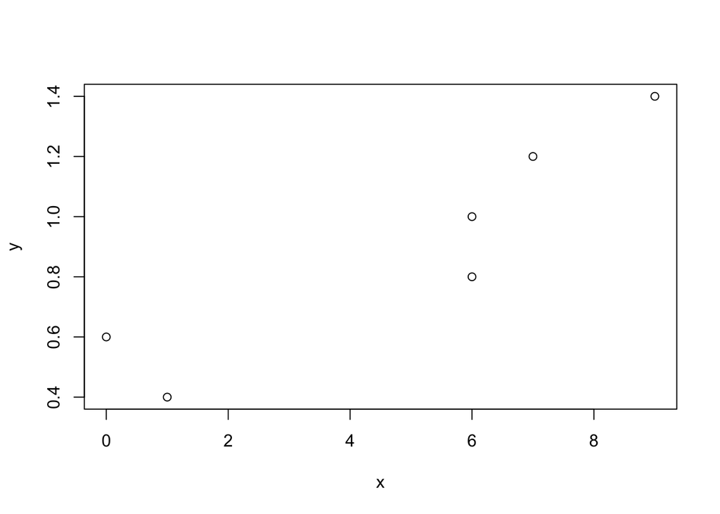

```r
plot(x=q2_df$y, y=q2_df$x, xlab='x', ylab='y')
```

(c).

```r
get_dev_res <- function(y, mu){
  return(sign(y - mu) * sqrt(2 * y * log(y/mu) - (y-mu)))
}

get_dev_res(1, 0.37)
```

```
## [1] 1.165549
```

# Problem 3

Knight & Skagen collected the data shown in the table( and in data frame eagles) during a field study on the foraging behavior of wintering Bald Eagles in Washington State, USA. The data concern 160 attempts by one (pirating) Bald Eagle to steal a chum salmon from another (feeding) Bald Eagle. The abbreviations used are L=Large, S = small A = adult I = immature Report on factors that explain the success of the pirating attempt and give a prediction formula for the probability of success

```r
q3_df <- eagles
eagles_glm <- glm(y/n ~ P*A + V,
                  data=q3_df,
                  family=binomial(link='logit'),
                  weights=n)

summary(eagles_glm)
```

```
##
## Call:
## glm(formula = y/n ~ P * A + V, family = binomial(link = "logit"),
##     data = q3_df, weights = n)
##
## Deviance Residuals:
##        1         2         3         4         5         6         7         8
## -0.02320   0.32133  -0.02030   0.31926   0.15434  -0.15279  -0.27823   0.04506
##
## Coefficients:
##             Estimate Std. Error z value Pr(>|z|)
## (Intercept)   0.8977     0.4480   2.004  0.04507 *
## PS           -3.4605     1.1287  -3.066  0.00217 **
## AI           -0.3590     0.5986  -0.600  0.54870
## VS            5.4324     1.3602   3.994  6.5e-05 ***
## PS:AI        -3.6614     1.6279  -2.249  0.02450 *
## ---
## Signif. codes:  0 '***' 0.001 '**' 0.01 '*' 0.05 '.' 0.1 ' ' 1
##
## (Dispersion parameter for binomial family taken to be 1)
##
##     Null deviance: 128.26734  on 7  degrees of freedom
## Residual deviance:   0.33274  on 3  degrees of freedom
## AIC: 23.073
##
## Number of Fisher Scoring iterations: 6
```

*Based on the summary object, at 0.1% significance code, the pirating eagle will have a higher success rate* *against a small sized feeding eagle(VS) which is why the coefficient in front of this term is the highest in magnitude and positive.* *Conversely, we see that at 1% significance code, if the pirating eagle is small, its success rate will decrease, explaining why* *the coefficient in front of (PS) is large in magnitude and negative.* *Finally, we see that the age of the pirating Eagle on its own is neither a significant contributor nor detractor. However, at the 5% significance code, when the pirating eagle is both immature and small, the effect of (AI) has an even greater adverse affect on the success rate then (PS) alone.*

# Problem 4.

A marketing research firm was engaged by an automobile manufacturer to conduct a pilot study to examine the feasibility of using logistic regression for ascertaining the likelihood that a family will purchase a new car during the next year. A random sample of 33 suburban families was selected. Data on annual family income (X1, in thousand dollars) and the current age of the oldest family automobile (X2, in years) were obtained. A follow-up interview conducted 12 months later was used to determine whether the family actually purchased a new car (Y = 1) or did not purchase a new car (Y = 0) during the year.

**Read in Problem 4 data**

```r
q4_df <- read.table('/Users/yanivbronshtein/Coding/Rutgers/Statistical_Computing_Repo/data/Stat567_hw2_problem4.txt', header=FALSE)
colnames(q4_df) <- c('Y', 'X1', 'X2')
```

1. Find the maximum likelihood estimates of $\beta_0, \beta_1, and\beta_2$. State the fitted response function.

```r
q4_glm <- glm(Y~., data=q4_df, family=binomial('logit'))
mle_estim <- q4_glm$coefficients

b0 <- mle_estim[[1]]; b1 <- mle_estim[[2]]; b2 <- mle_estim[[3]]
cat("Beta 0:", b0, " Beta 1:",b1, " Beta 2:", b2)
```

```
## Beta 0: -4.739309  Beta 1: 0.06773256  Beta 2: 0.5986317
```

**Response Function**

1/(1+exp(-(b0+(b1*50)+(b2*3))))

```r
response_function <- function(B,X){
  temp <- exp(B[1] + B[2]*X[1] + B[3]*X[2])

  return(as.numeric(temp/(1+temp)))
}
```

2. Obtain exp($\beta_1$) and exp($\beta_2$) and interpret these numbers.

```r
cat("exp(Beta 1):", exp(b1),"\n", "exp(Beta 2):", exp(b2))
```

```
## exp(Beta 1): 1.070079
##  exp(Beta 2): 1.819627
```

*Taking the exponential of our logit function gives us an understanding of our independent* *variables on the odds ratio. In our case exp(Beta 2) is almost twice as likely to occur as* *opposed to not occur. Thus, the age of the car has a higher impact on the likelihood of a sale* *than the income of the potential buyer.*

3. What is the estimated probability that a family with annual income of $50 thousand and an oldest car of 3 years will purchase a new car next year?

```r
prob <- response_function(B=c(b0,b1,b2), X=c(50.0,3.0))
prob
```

```
## [1] 0.6090245
```

4. Obtain the deviance residuals and present them in an index plot. Do there appear to be any outlying cases?

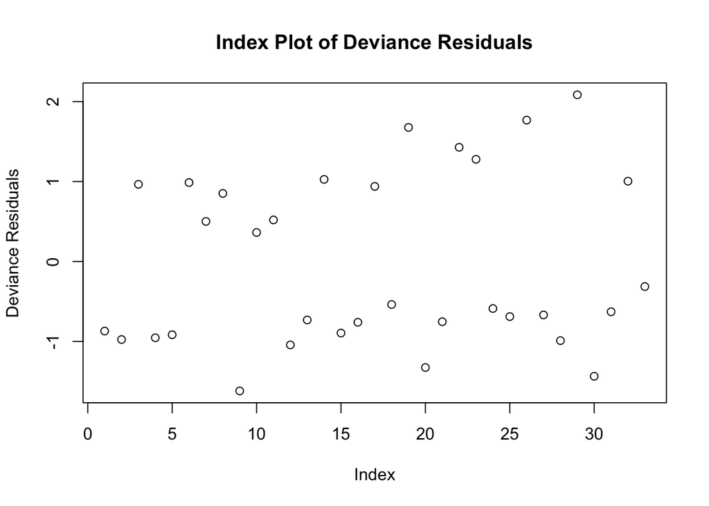

```r
dev <- resid(q4_glm, type="deviance")
dev <- unname(dev)
plot(dev,ylab="Deviance Residuals",main="Index Plot of Deviance Residuals")
```

(e) Construct a half-normal probability plot of the absolute deviance residuals. Do any cases here appear to be outlying?

```r
hnp(q4_glm,xlab="Percentile",main="Absolute Value of Deviance Residuals")
```

```
## Binomial model
```

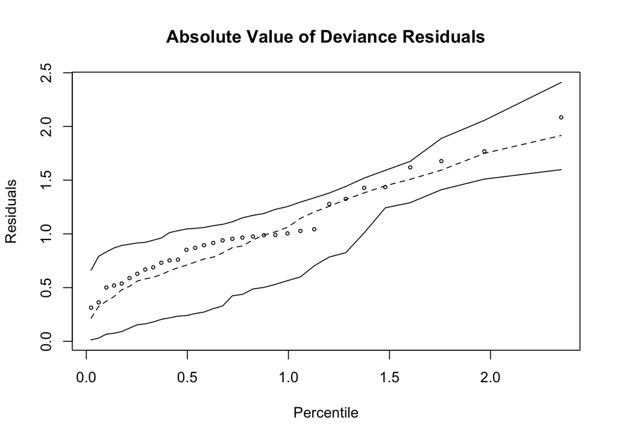

```r
K <- function(elem){
  return((0.05-elem)/.22)
}

arr <- c(-1.43,-.95,-.19,.02,.14,.83,1.35,1.46, 2.62)
for(elem in arr){
  cat(K(elem),'\n')
}
```

```
## 6.727273
## 4.545455
## 1.090909
## 0.1363636
## -0.4090909
## -3.545455
## -5.909091
## -6.409091
## -11.68182
```